Estadística 1 | 2020

# Guía de Clase del TP4: Distribuciones de Probabilidad Continuas

Estadística 1 | 2020

Docentes: Patricia M. Acetta y Agustin Alesso

# Distribución de Probabilidades de Variables Aleatorias Continuas

Una variable aleatoria continua tiene un número infinito de valores, y esos valores pueden asociarse con mediciones en una escala continua, de manera que no existan huecos o interrupciones.

Si una variable aleatoria continua tiene una distribución con una gráfica simétrica y en forma de campana, decimos que tiene una distribución normal.

## Curva de densidad

Es una gráfica de una distribución de probabilidad continua. Debe satisfacer las siguientes propiedades:

1. El área total bajo la curva debe ser igual a 1.
2. Cada punto de la curva debe tener una altura vertical igual o mayor que 0. (Es decir, la curva no puede estar por debajo del eje $x$).

*Dado que el área total bajo de la curva de densidad es igual a 1, existe una correspondencia entre área y probabilidad.*

## Distribución uniforme

Una variable aleatoria continua tiene una distribución uniforme si sus valores se dispersan uniformemente a través del rango de valores posibles. La gráfica de una distribución uniforme tiene forma rectangular.

**Ejemplo:** *Un tambo robotizado, tiene registro del tiempo que lleva ordeñar cada vaca. El tiempo para ordeñar cada vaca es de aproximadamente entre 5 y 7 minutos para cada una.*

[figure not shown]

La distribución uniforme nos facilita ver estas dos propiedades muy importantes:

1. el área bajo la curva de una distribución de probabilidad es igual a 1
2. las probabilidades se calculan midiendo el área bajo la curva ya que existe una correspondencia entre ambas

La curva de densidad de una distribución uniforme es una línea horizontal, de manera que es fácil calcular el área de cualquier región rectangular: multiplicando anchura por altura.

## Distribución normal estándar

Propiedades:

1. presenta forma de campana
2. posee una media igual a 0: $\mu = 0$
3. tiene una desviación estándar igual a 1: $\sigma = 1$

## Regla Empírica

Para los conjuntos de datos que tienen una distribución aproximadamente normal, se aplican las siguientes propiedades:

- Aproximadamente 68% de todos los valores caen dentro de 1 desviación estándar de la media: $P(\mu - \sigma \le X \le \mu + \sigma) \approx 0.6826$
- Aproximadamente 95% de todos los valores caen dentro de 2 desviaciones estándar de la media: $P(\mu - 2\sigma \le X \le \mu + 2\sigma) \approx 0.9544$
- Aproximadamente 99.7% de todos los valores caen dentro de 3 desviaciones estándar de la media: $P(\mu - 3\sigma \le X \le \mu + 3\sigma) \approx 0.9974$

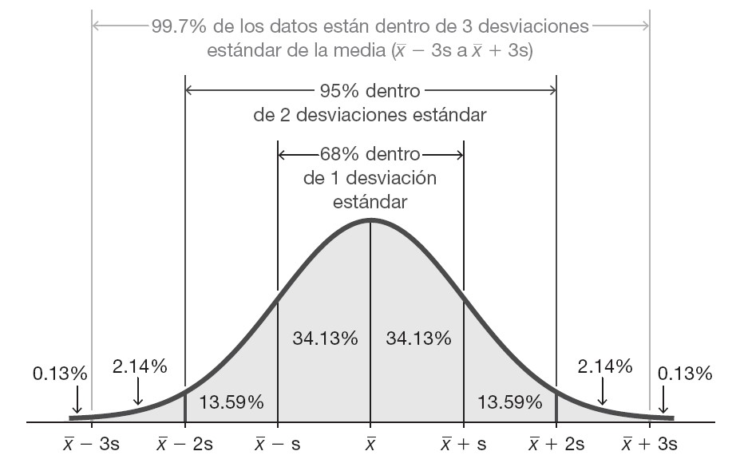

En éste TP vamos a calcular áreas (o probabilidades) correspondientes a diversas regiones debajo de la gráfica de la distribución normal estándar. También vamos a calcular valores de la variable z que corresponden a áreas debajo de la curva.

Existen muchas distribuciones normales diferentes, las cuales dependen de dos parámetros: la media poblacional $\mu$ y la desviación estándar poblacional $\sigma$.

**Definición**

La distribución normal estándar es una distribución normal de probabilidad con $\mu=0$ y $\sigma=1$, y el área total debajo de su curva de densidad es igual a $1$.

**Cálculo de probabilidades con puntuaciones z**

Puntuación z: Distancia a lo largo de la escala horizontal de la distribución normal estándar

Área: Región bajo la curva

Mediante la estandarización se facilita el cálculo de probabilidades:

$$Z = \dfrac{X - \mu}{\sigma} \sim N(0,1)$$

**Calculo de probabilidades y percentiles**

En **R** las funciones de probabilidad normal se obtienen con las funciones de la familia `*norm()`

- `dnorm(x, mean, sd)` devuelve la densidad de probabilidad en $X$ (**no es la probabilidad**)
- `pnorm(q, mean, sd, lower.tail)` devuelve la probabilidad acumulada hasta $x_0$ o sea $P(X \le x_0)$
- `qnorm(p, mean, sd, lower.tail)` devuelve el cuantil de una distribución normal para un valor de probabilidad acumulada, es decir $P(X \le a) = p$
- `rnorm(n, mean, sd)` devuelve una muestra aleatoria de tamaño `n` de una población normal

Los argumentos:

- `x` es el valor de la variable $X$ cuya densidad de probabilidad se quiere averiguar
- `q` es el valor de la variable $X$ cuya probabilidad acumulada se quiere averiguar
- `p` es el valor de probabilidad acumulada cuyo cuantil se desea averiguar
- `mean` es la media de la distribución normal (por defecto `mean = 0`, es decir, distribución $Z$)
- `sd` es la desviación estándar de la distribución normal (por defecto `sd = 1`, es decir, distribución $Z$)
- `lower.tail` es para indicar, en las distribuciones acumulada si lo que se desea es $P(X \le x)$ (por defecto `TRUE`) o $P(X > x)$ usando `lower.tail = F`
- `n` tamaño de la muestra

## Ejercicio 1

En un establecimiento lechero del Departamentos las Colonias se lleva registro de las producciones de leche. Éstos registros indican que la producción de leche por vaca por día sigue una distribución normal, promedio $\mu=25$ litros y con un desvío $\sigma=3$ litros.

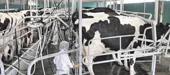

**Responder:**

Si un día se decide visitar el establecimiento:

## Item (a).

**¿Cuál es la probabilidad de que la producción de ese día, sea de exactamente 25 litros?**

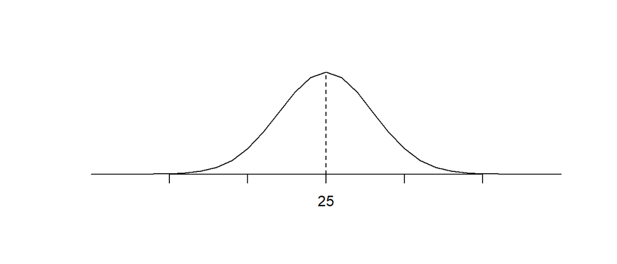

*Queremos calcular la probabilidad:* $P(x=25)$

La producción de leche es una variable continua y 25 litros es uno de los infinitos números que puede tomar por lo tanto su probabilidad es 0.

*NO utilizaremos la funcion `dnorm()` porque ésta función NO calcula propabilidad, sino que devuelve la densidad de probabilidad*

## Item (b).

**¿Cuál es la probabilidad de que la producción de ese día, sea mayor a 20 litros?**

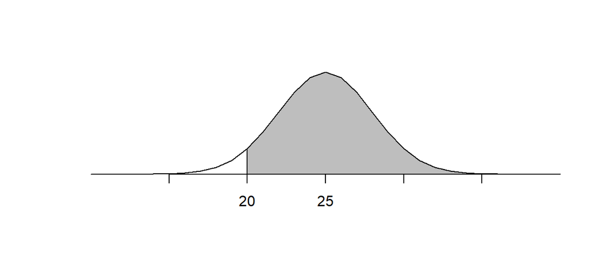

*Queremos calcular la probabilidad acumulada:* $P(x>20)$

*No importa si queremos incluir o no al 25 (recordar que la probabilidad en el punto es = 0, por lo tanto no cambia el resultado*

*Utilizaremos la funcion `pnorm()` porque queremos calcular la probabilidad acumulada*

Pasos:

**Paso 1:** definimos los parámetros de la distribución normal:

$\mu= 25$ litros, media de producción de leche

$\sigma= 3$ litros, desviación estándar de la producción de leche

```r
mu <- 25
sigma <- 3
```

**Paso 2:** otros argumentos que necesitaremos para usar la función:

Para definir `q`, no importa si lo queremos incluir o no, corresponde al valor de x incognita, en éste caso 20.

```r
q <- 20
```

**Paso 3:** Ingresamos todos los argumentos en la función:

```r
pnorm(q = q, mean = mu, sd = sigma, lower.tail = F)
```

```
[1] 0.9522096
```

Nos indica un valor de 0.9522096.

Expresado en porcentaje:

*Respuesta:* 95.22% es la probablidad de que la extracción de leche de ese día sea mayor a 20 litros por vaca.

## Item (c).

**¿Cuál es la probablidad de que la producción de ese día, sea menor de 18 litros?**

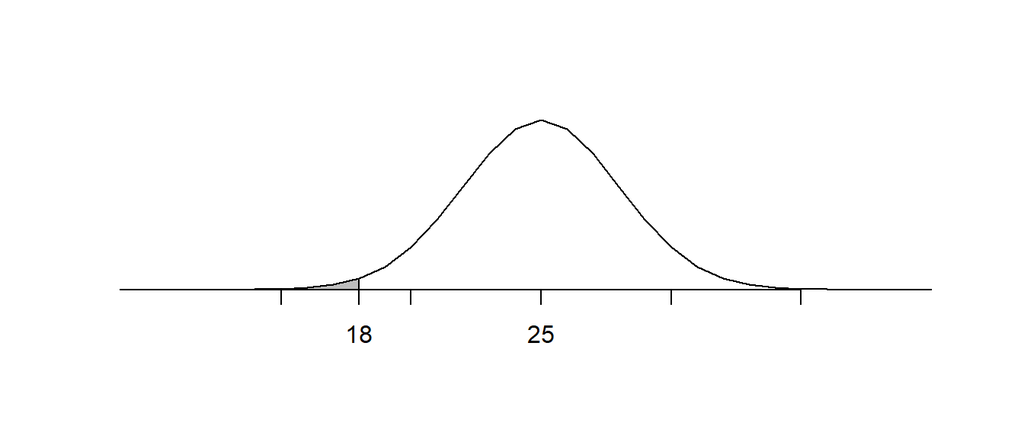

*Queremos calcular la probabilidad acumulada:* $P(x<18)$

*No importa si queremos incluir o no al 10 (recordar que la probabilidad en el punto es = 0, por lo tanto no cambia el resultado*

*Utilizaremos la funcion `pnorm()` porque queremos calcular la probabilidad acumulada*

Pasos:

**Paso 1:** definimos los parámetros de la distribución normal:

$\mu= 25$ litros, media de producción de leche

$\sigma= 3$ litros, desviación estándar de la producción de leche

Ya los definimos antes:

```r
mu
```

```
[1] 25
```

```r
sigma
```

```
[1] 3
```

**Paso 2:** otros argumentos que necesitaremos para usar la función:

Para definir `q`, no importa si lo queremos incluir o no, corresponde al valor de x incognita, en éste caso 18

```r
q <- 18
```

**Paso 3:** Ingresamos todos los argumentos en la función:

```r
pnorm(q = q, mean = mu, sd = sigma)   # lower.tail = T por defecto
```

```
[1] 0.009815329
```

Nos indica un valor de 0.0098153.

Expresado en porcentaje:

*Respuesta:* 0.98% es la probablidad de que la extracción de leche de ese día sea menor a 18 litros por vaca.

## Item (d).

**¿Cuál es la probablidad de que la producción de ese día, sea mayor de 20 litros y menor de 30 litros?**

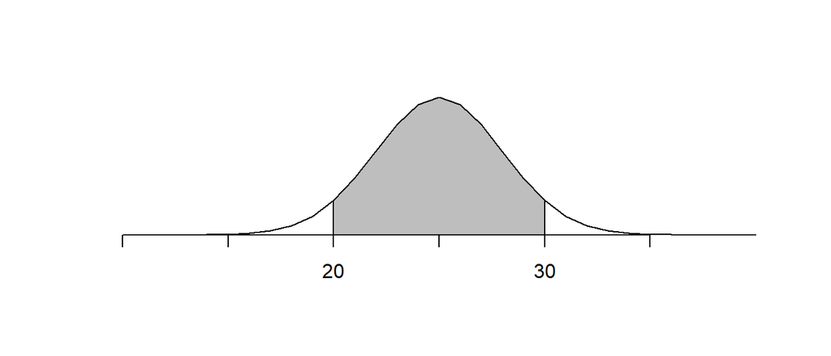

*Queremos calcular la probabilidad acumulada entre:* $P(20<x<30)$

*No importa si queremos incluir o no al 20 y al 30 (recordar que la probabilidad en el punto es = 0, por lo tanto no cambia el resultado*

*Utilizaremos la funcion `pnorm()` porque queremos calcular la probabilidad acumulada*

Pasos:

**Paso 1:** definimos los parámetros de la distribución normal:

$\mu= 25$ litros, media de producción de leche

$\sigma= 3$ litros, desviación estándar de la producción de leche

Ya los definimos antes:

```r
mu
```

```
[1] 25
```

```r
sigma
```

```
[1] 3
```

**Paso 2:** otros argumentos que necesitaremos para usar la función:

Para definir `q`, no importa si lo queremos incluir o no, corresponde al valor de x incognita, en éste caso 20 y 30.

```r
q1 <- 20
q2 <- 30
```

**Paso 3:** ingresamos todos los argumentos en la función, podemos hacerlo de 2 maneras:

Alternativa 1: restando probabilidades acumuladas, calculandolas por separado

```r
P_20 <- pnorm(q = q1, mean = mu, sd = sigma)   # lower.tail = T por defecto
P_30<- pnorm(q = q2, mean = mu, sd = sigma)   # lower.tail = T por defecto

P_30 - P_20           # valor mayor - menor
```

```
[1] 0.9044193
```

Alternativa 2: usando la función `diff()` para calcular diferencias (resta)

```r
diff(pnorm(q = c(q1,q2), mean = mu, sd = sigma))
```

```
[1] 0.9044193
```

```r
# en el vector q = c(q1, q2), primero el valor menor y luego el mayor
```

Nos indica un valor de 0.9044193.

Expresado en porcentaje:

*Respuesta:* 90.44% es la probablidad de que la extracción de leche de ese día esté entre 20 y 30 litros por vaca.

## Distribución de la media muestral

La distribución de probabilidad de un estadístico se denomina distribución muestral. La distribución de la media muestral es aquellan distribución de todos los valores de la media cuando se obtienen todas las muestras posibles del mismo tamaño $n$ de la misma población.

El valor de un estadístico, como la media muestral $\bar X$ depende de los valores particulares incluidos en la muestra y generalmente varía de una muestra a otra. Esta variabilidad de un estadístico se denomina **variabilidad de muestreo**.

### Teorema del límite central

El teorema del límite central y la distribución muestral de la $\bar X$

**Dado que:**

1. La variable aleatoria x tiene una distribución (que puede o no ser normal) con media $\mu$ y desviación estándar $\sigma$.
2. Todas las muestras aleatorias del mismo tamaño n se seleccionan de la población. (Las muestras se seleccionan de manera que todas las muestras posibles de tamaño $n$ tengan la misma probabilidad de ser seleccionadas).

**Conclusiones:**

1. Conforme el tamaño de la muestra aumenta, la distribución de las medias muestrales se aproximará a una distribución normal.
2. La media de todas las medias muestrales es la media poblacional $\mu$. (Es decir, la distribución normal de la conclusión 1 tiene una media $\mu$).
3. La desviación estándar de todas las medias muestrales es $\sigma/\sqrt n$ (es decir, la distribución normal de la conclusión 1 tiene una desviación estándar $\sigma/\sqrt n$)

**Reglas prácticas de uso común**

1. Si la población original no está distribuida normalmente, la siguiente es una directriz común: para muestras de tamaño n mayores que 30, la distribución de las medias muestrales puede aproximarse razonablemente bien por medio de una distribución normal. (Excepciones: poblaciones con distribuciones muy diferentes a la normal, que requieren tamaños de muestra mucho más grandes que 30). La aproximación mejora a medida que el tamaño muestral $n$ aumenta.
2. Si la población original se distribuye normalmente, entonces las medias muestrales estarán distribuidas normalmente para *cualquier* tamaño de muestra $n$ (no sólo los valores de $n>30$).

*El teorema del límite central implica dos distribuciones diferentes: la distribución de la población original y la distribución de las medias muestrales.*

**Notación**

Si se seleccionan todas las muestras aleatorias posibles de tamaño $n$ de una población con media $\mu$ y desviación estándar $\sigma$, entonces:

- Media de las medias muestrales: $\mu_\bar X = \mu$
- Desviación estándar de las medias muestrales (error estándar de la media): $\sigma_\bar X = \frac{\sigma}{\sqrt n}$

**Exploración del teorema del límite central**

El teorema del límite central es uno de los resultados más importantes en estadística.

De manera informal, el teorema del límite central dice que la distribución normal está en todas partes.

Sin importar qué distribución de probabilidad subyace en un experimento, existe una distribución correspondiente de medias que tendrá una forma aproximadamente normal.

## Ejercicio 2

La capacidad para transportar vacunos en un camión de 30 m<sup>2</sup> de jaula es de 13200 kg, para 33 animales de 400 kg.

Los animales que entregará un productor para que ese camión jaula transporte, tienen una media $\mu=450$ kg con una desviación estándar de $\sigma=25$ kg cada uno.

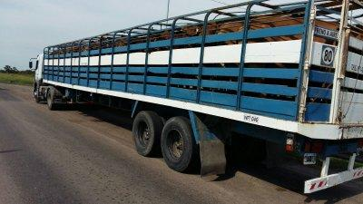

**Responder:**

## Item (a).

**¿Cuál es la probabilidad de que en una muestra de 20 animales, el peso promedio sea mayor a 460 kg?**

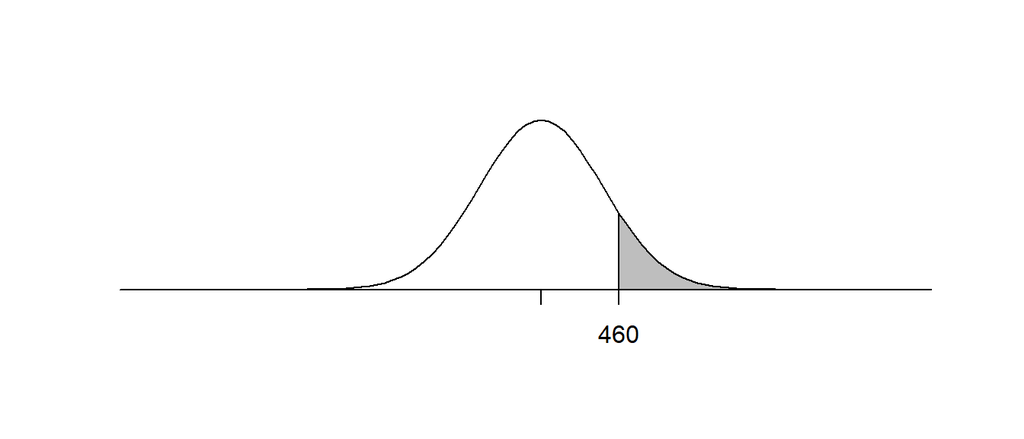

*Queremos calcular la probabilidad acumulada:* $P(\bar{X} > 460)$

*No importa si queremos incluir o no al 460 (recordar que la probabilidad en el punto es = 0, por lo tanto no cambia el resultado*

*Utilizaremos la funcion `pnorm()` porque queremos calcular la probabilidad acumulada*

Pasos:

**Paso 1:** definimos los parámetros de la distribución normal de la **media**:

$\mu_\bar{X} = \mu = 450$ kg, media de peso de los animales del establecimiento

$\sigma_\bar X = \frac{\sigma}{\sqrt n} = \frac{25}{\sqrt 20}$ litros, desviación estándar de la producción de leche para una muestra de 20 animales

```r
n<- 20   # animales de la muestra
mu_xbar <- 450
sigma_xbar <- 25/sqrt(n)
```

**Paso 2:** otros argumentos que necesitaremos para usar la función:

Para definir `q`, no importa si lo queremos incluir o no, corresponde al valor de x incognita, en éste caso 460.

```r
q <- 460
```

**Paso 3:** Ingresamos todos los argumentos en la función:

*`lower.tail = F` ya que queremos calcular valores mayores a 460*

```r
pnorm(q = q, mean = mu_xbar, sd = sigma_xbar, lower.tail = F)
```

```
[1] 0.03681914
```

Nos indica un valor de 0.0368191.

Expresado en porcentaje:

*Respuesta:* 3.68% es la probablidad de que en una muestra de 20 animales, el peso promedio sea mayor a 460 kg.

## Item (b).

**¿Cuál es la probabilidad de que en una muestra de 5 animales, el peso promedio sea menor a 430 kg?**

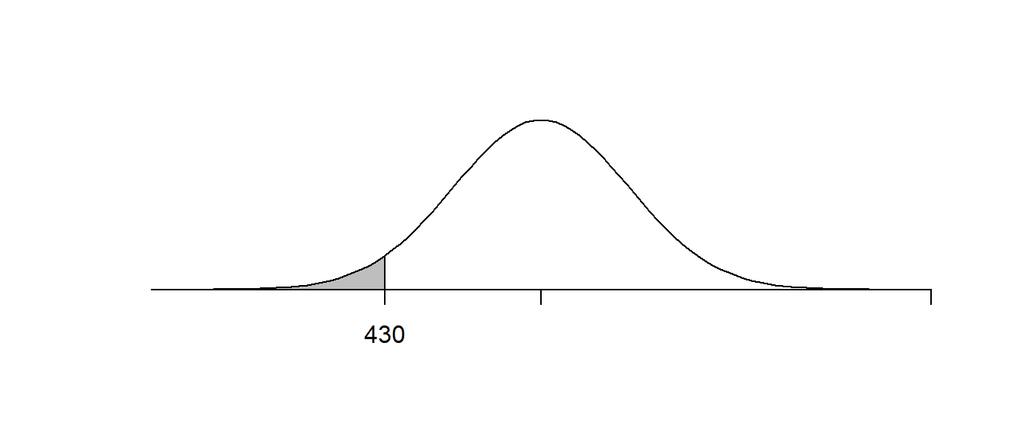

*Queremos calcular la probabilidad acumulada:* $P(\bar X < 430)$

*No importa si queremos incluir o no al 430 (recordar que la probabilidad en el punto es = 0, por lo tanto no cambia el resultado*

*Utilizaremos la funcion `pnorm()` porque queremos calcular la probabilidad acumulada*

Pasos:

**Paso 1:** definimos los parámetros de la distribución normal de la **media**:

$\mu_\bar X = 450$ kg, media de peso de los animales del establecimiento

$\sigma_\bar X = \frac{25}{\sqrt 5}$ litros, desviación estándar de la producción de leche para una muestra de 5 animales

```r
n<- 5   # animales de la muestra
mu_xbar <- 450
sigma_xbar <- 25/sqrt(n)
```

**Paso 2:** otros argumentos que necesitaremos para usar la función:

Para definir `q`, no importa si lo queremos incluir o no, corresponde al valor de x incognita, en éste caso 430.

```r
q <- 430
```

**Paso 3:** Ingresamos todos los argumentos en la función:

*`lower.tail = T` por defecto, queremos calcular valores menores a 430*

```r
pnorm(q = q, mean = mu_xbar, sd = sigma_xbar)    # lower.tail = T, por defecto
```

```
[1] 0.03681914
```

Nos indica un valor de 0.0368191.

Expresado en porcentaje:

*Respuesta:* 3.68% es la probablidad de que en una muestra de 5 animales, el peso promedio sea menor a 430 kg.

## Item (c).

**¿Cuál es la probabilidad de que en una muestra de 5 animales, el peso promedio sea mayor a 430 y menor a 450 kg?**

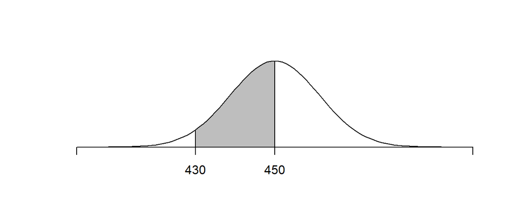

*Queremos calcular la probabilidad acumulada:* $P(430< \bar X <450)$

*No importa si queremos incluir o no al 430 y 450 (recordar que la probabilidad en el punto es = 0, por lo tanto no cambia el resultado*

*Utilizaremos la funcion `pnorm()` porque queremos calcular la probabilidad acumulada*

Pasos:

**Paso 1:** definimos los parámetros de la distribución normal de la **media**:

$\mu_\bar X= 450$ kg, media de peso de los animales del establecimiento

$\sigma_\bar X= \frac{25}{\sqrt 5}$ litros, desviación estándar de la producción de leche para una muestra de 5 animales

```r
n<- 5   # animales de la muestra
mu_xbar <- 450
sigma_xbar <- 25/sqrt(n)
```

**Paso 2:** otros argumentos que necesitaremos para usar la función:

```r
q1 <- 430
q2 <- 450
```

**Paso 3:** ingresamos todos los argumentos en la función, podemos hacerlo de 2 maneras:

Alternativa 1: restando probabilidades acumuladas, calculandolas por separado

```r
P_430 <- pnorm(q = q1, mean = mu_xbar, sd = sigma_xbar)   # lower.tail = T por defecto
P_450<- pnorm(q = q2, mean = mu_xbar, sd = sigma_xbar)   # lower.tail = T por defecto

P_450 - P_430           # valor mayor - menor
```

```
[1] 0.4631809
```

Alternativa 2: usando la función `diff()` para calcular diferencias (resta)

```r
diff(pnorm(q = c(q1,q2), mean = mu_xbar, sd = sigma_xbar))
```

```
[1] 0.4631809
```

```r
# en el vector q = c(q1, q2), primero el valor menor y luego el mayor
```

Nos indica un valor de 0.4631809.

Expresado en porcentaje:

*Respuesta:* 46.32% es la probablidad de que en una muestra de 5 animales, el peso promedio esté entre 430 y 450 kg.

## Item (d).

**¿Cuál es la probabilidad de que en una muestra de 10 animales, el peso promedio sea exactamente 450 kg?**

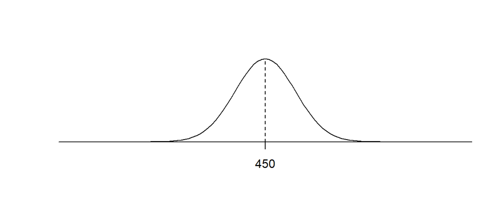

*Queremos calcular la probabilidad:* $P(\bar{X} = 450)$

Los kg de peso de un animal es una variable continua y 450 kg es uno de los infinitos números que puede tomar por lo tanto su probabilidad es 0.

# Determinación de normalidad

Gráfico QQPLOT

Una gráfica cuantilar normal (o gráfica de probabilidad normal) es una gráfica de puntos (x, y) donde cada valor x proviene del conjunto original de datos muestrales, y cada valor y es la puntuación z correspondiente, que es un valor cuantilar esperado de la distribución normal estándar.

El objetivo del gráfico QQplot es evaluar el ajuste de los datos que trabajemos, a la distribución normal.

Graficamos en **R**, los datos de `peso_bovinos.xlsx` que corresponden al los pesos de los animales del establecimiento del Ejercicio 2.

Importamos los datos:

```r
# activamos el paquete `readxl`
library(readxl)
datos <- read_xlsx("peso_bovinos.xlsx")
```

El gráfico lo realizamos con la función `ggplot()` del paquete `ggplot2`

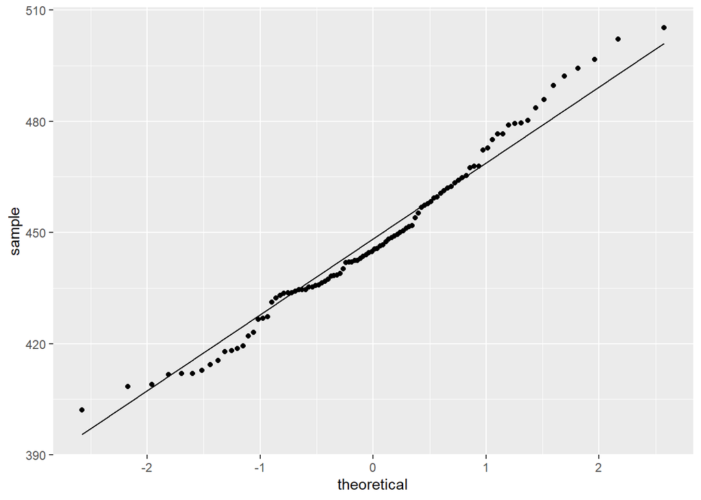

```r
# activamos el paquete

library(ggplot2)

# indicamos los argumentos correspondientes

ggplot(datos, aes(sample = Peso)) +
  stat_qq() +
  stat_qq_line()
```

Interpretación:

Dado que el gráfico QQPlot permite observar cuan cerca está la distribución de un conjunto de datos a alguna distribución ideal, para el caso de los Pesos de los animales del estableciminto, se compara la distribución de los datos de Pesos, con la distribución teoría de los cuantiles de la distribución normal.

Se observa que la mayoría de los puntos se aproximan a la recta 1:1, por lo tanto podemos decir que los datos de los Pesos de los animales siguen una distribución normal.

Material preparado por [Cátedra de Estadística FCA-UNL](https://github.com/estadistica-fcaunl/)